# Computational Linear Algebra Homework 1: Programming Practice and Root Finding

Vichearith Meas

*Due Monday, January 31, 2021, 11:59PM. Please submit an html of your completed work on Moodle*

Reminder: you are allowed — and in fact encouraged — to work on and discuss homework together. You should, however, write up your own assignments in your own words. If you work with another person or if you get significant help from a classmate or external resource, you should give that person or resource credit in your solution (at no penalty to you).

# Part I: Programming Practice

## Problem 1: A Sum

Write a program called *mytrisum* to calculate the sum of the first $n$ numbers in the progression $2,5,8,11,\cdots$. As an example, mytrisum(3) should return 15 and mytrisum(42) should return the value of
$$\sum_{n=1}^{42} (3n-1).$$
Illustrate your program by calling mytrisum(102030).

There is neither a bonus nor a penalty for really fast or slow code. I suggest writing multiple versions of the program using different strategies. Here are three ideas: use a for-loop, use sum(v) after building the right v, or work out the sum on paper so that your program can be really simple.

```r
# 'For loop'
mytrisum_for = function(x){
  sum = 0
  for(i in 1:x){
    sum =sum + 3*i - 1
  }
  return(sum)
}
mytrisum_for(3) # 15
```

```
## [1] 15
```

```r
mytrisum_for(42)#2667
```

```
## [1] 2667
```

```r
mytrisum_for(102030) # 15615232365
```

```
## [1] 15615232365
```

```r
# 'Vector'
mytrisum_vector = function(x){
  v = c(1:x)
  v = 3*v - 1
  return(sum(v))
}
mytrisum_vector(3) # 15
```

```
## [1] 15
```

```r
mytrisum_vector(42)#2667
```

```
## [1] 2667
```

```r
mytrisum_vector(102030) # 15615232365
```

```
## [1] 15615232365
```

```r
# 'Formula'
mytrisum_formula = function(x){
  return((3*x^2 + x)/2)
}
mytrisum_formula(3) # 15
```

```
## [1] 15
```

```r
mytrisum_formula(42)#2667
```

```
## [1] 2667
```

```r
mytrisum_formula(102030) # 15615232365
```

```
## [1] 15615232365
```

## Problem 2: Office Space

The point of this problem is twofold: (i) to illustrate what can happen if you accumulate many truncations of numbers and (ii) to give you practice writing programs.

In the 1999 movie Office Space, a character creates a program that takes fractions of cents that are truncated in a bank’s transactions and deposits them into his own account. This is not a new idea, and hackers who have actually attempted it have been arrested. In this exercise you will simulate the program to determine how long it would take to become a millionaire this way.

Assume the following details:

- You have access to 10,000 bank accounts
- Initially, the bank accounts have values that are uniformly distributed between $100 and $100,000
- The nominal annual interest rate on the accounts is 5%
- The daily interest rate is thus .05/365
- Interested is compounded each day and added to the accounts, except that fractions of a cent are truncated
- The truncated fractions are deposited into an illegal account that initially has a balance of $0
- The illegal account can hold fractional values and it also accrues daily interest

Your job is to write an R script that simulates this situation and finds how long it takes for the illegal account to reach a million dollars.

Here is some R help:

The following code generates the initial accounts:

```r
accounts <- runif(10000,100,100000)
accounts <- floor(accounts*100)/100
```

The first line sets up 10,000 accounts with values uniformly between 100 and 100,000 The second line removes the fractions of cents (look at the data before and after that line is applied). To calculate interest for one day:

```r
interest <- accounts*(.05/365)
# head(interest)
```

Depending on how you do it, you might want to use an if-then statement. For example, you might use something like

```
if (illegal > 1000000) break
```

The `break` command breaks out of a loop. Or, perhaps more elegantly, you might use a `while` loop

```
while (illegal < 1000000) { do stuff here }
```

```r
#  FUNCTION: take original account, calculate the sum of illegal money after truncated
get_truncated_sum = function(original_accounts){
  #  Account balance after truncations
  truncated_accounts = floor(original_accounts*100)/100
  #  Return illegal money gain
  return(sum(original_accounts - truncated_accounts))
}

# FUNCTION: take accounts and return final balance after adding interest
add_compound_interest = function(accounts, interest_rate){
  return(accounts*(1 + interest_rate))
}

# FUNCTION: return the update balance in one iteration
accumulate_money = function(target_accounts, balance, rate){
  # Compound interest
  target_accounts  = add_compound_interest(target_accounts,rate)
  balance = add_compound_interest(balance,rate)
  # Add earning
  balance = balance +  get_truncated_sum(target_accounts)
  return(balance)
}
```

```r
# MAIN FUNCTION: Simulate the situation and finds how many day it takes for the illegal account to reach a million dollars

simulate = function(){

  INTEREST_RATE = 0.5/356
  my_account = 0
  day_count = 0

  while(my_account < 1000000){
      my_account = accumulate_money(accounts, my_account, INTEREST_RATE)
      day_count = day_count + 1
  }
  cat('Final Day Count : ', day_count, ' days or ', round(day_count/365,2 ),'years' , end='\n')
  cat('Illegal Account Balance : $', my_account)
}

simulate()
```

```
## Final Day Count :  2402  days or  6.58 years
## Illegal Account Balance : $ 1000956
```

## Problem 3: Arithmetic-Geometric Mean

The arithmetic mean of $a$ and $b$ is $\frac{a+b}{2}$. The geometric mean of two positive numbers $a$ and $b$ is $\sqrt{ab}$.  
To compute the *arithmetic-geometric mean* of two positive numbers, do the following. First, compute their arithmetic and geometric means and call these numbers $A$ and $G$. Then compute the arithmetic and geometric means of $A$ and $G$ and overwrite the old values of $A$ and $G$ with these new ones. Repeat this for a while and you will find that $A$ and $G$ get closer and closer together. Eventually they will look identical. The number that they converge to is called the arithmetic-geometric mean of the two original numbers.

1. Write a function called “my.agm” that computes the arithmetic-geometric mean of two input numbers. Test it by finding the agm of these pairs of numbers: $(10,50)$; $(1,100)$; $(10^{-10}, 10^{10})$. You can do this by correcting the following code chunk:

   ```r
   my.agm <- function(a,b){
     # add your code here to find the agm of the inputs "a" and "b"
     # You'll probably need a for-loop or a while-loop
     # suppose your answer is stored as "C"
     A = (a + b)/2
     G = sqrt(a*b)
     tol = 10^-13

     while (abs(A-G) > tol){
       AA = (A + G)/2
       GG = sqrt(A*G)
       A = AA
       G = GG
       }

     C = G
     return(C)
   }

   print(my.agm(10,50))
   ```

   ```
   ## [1] 26.04008
   ```

   ```r
   print(my.agm(1,100))
   ```

   ```
   ## [1] 26.21669
   ```

   ```r
   print(my.agm(1e-10,1e10))
   ```

   ```
   ## [1] 331126197
   ```

2. Define $f(x)$ as the arithmetic-geometric mean of $2$ and $x$. Make a plot showing $f(x)$ for $x \in [1,10]$ (e.g., use 900 $x$ values evenly spaced in this interval). You may want to use a for-loop to find the values of $f(x) = agm(2,x)$ for each value of $x$.

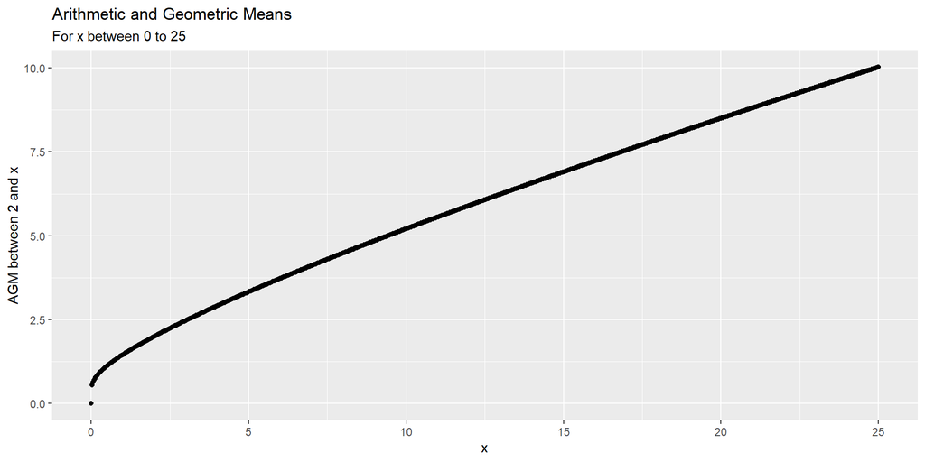

   ```r
   library(ggplot2)

   ### Function f(x) as the arithmetic-geometric mean of $2$ and $x$
   f = function(x){
     return(my.agm(2,x))
   }

   ### Plotting: calculate interval 1:x and plot f(x)
   plot_f = function(x){
     #  create 900 points between 0:x interval
     result = data.frame(x = seq(from = 0, to = x, length.out = 900), y = 0)
     #  loop through each point to get value of f(x)
     for (i in 1:nrow(result)){
       result[i,2] = f(result[i,1])
     }
     #  plot the value
     qplot( result[,1],
            result[,2],
            ylab = "AGM between 2 and x",
            xlab = 'x',

            )+
     ggtitle("Arithmetic and Geometric Means " )+
       labs(subtitle = paste0('For x between 0 to ',x))
   }

   # plot_f2 = function(x){
   #   #  create 900 points between 0:x interval
   #   x = seq(from = 0, to = x, length.out = 900)
   #   #  plot the value
   #   qplot( x,
   #          f(x),
   #          ylab = "AGM between 2 and x",
   #          xlab = 'x'
   #          )+
   #   ggtitle("Arithmetic and Geometric Means")
   # }


   plot_f(25)
   ```

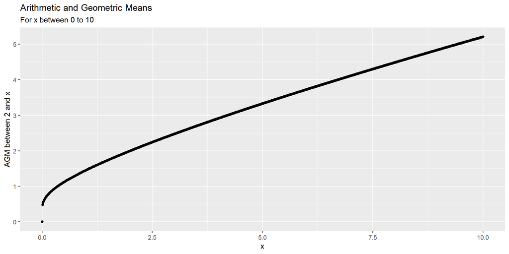

   ```r
   plot_f(10)
   ```

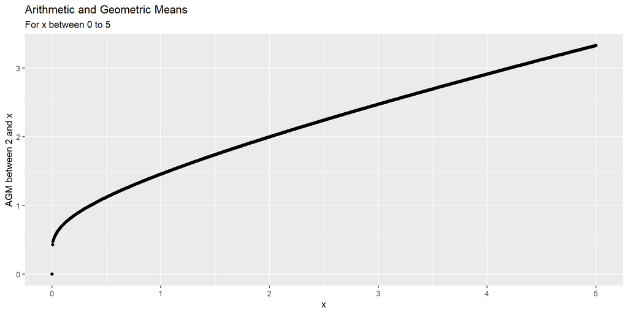

   ```r
   plot_f(5)
   ```

3. Somehow, find an estimate of the derivative $f'$ at $x=5$, that is, find the slope of the tangent line to the graph you just made at $x=5$. One way is to use find the slope of a line that passes through two nearby points on the graph, such as

   $$f'(5) \approx \frac{f(5+h) - f(a)}{h}$$
   or, more symmetrically,

   $$f'(5) \approx \frac{f(5+h) - f(5-h)}{2h}$$

   where $h$ is some pretty small but nonzero number.

   ```r
   derivative <- function(f,x,tol=0.5*10^-15,max.its=60){
     history <- rep(NA, max.its)
     h = x
     result = (f(x + h) - f(x - h))/2*h
     for( i in 1:max.its){
       history[i] = result
       if(h <= tol){
         break
       }

       h = h/2
       result = (f(x + h) - f(x - h))/(2*h)
       }
     return(list(estimate = result,history = history))
   }

   derivative(f, 5)
   ```

   ```
   ## $estimate
   ## [1] 0
   ##
   ## $history
   ##  [1] 13.0200410  0.4114554  0.4072778  0.4063461  0.4061192  0.4060628
   ##  [7]  0.4060487  0.4060452  0.4060443  0.4060441  0.4060440  0.4060440
   ## [13]  0.4060440  0.4060440  0.4060440  0.4060440  0.4060440  0.4060440
   ## [19]  0.4060440  0.4060440  0.4060440  0.4060440  0.4060440  0.4060440
   ## [25]  0.4060440  0.4060440  0.4060440  0.4060440  0.4060440  0.4060440
   ## [31]  0.4060440  0.4060441  0.4060442  0.4060440  0.4060448  0.4060455
   ## [37]  0.4060425  0.4060486  0.4060547  0.4060547  0.4060547  0.4060547
   ## [43]  0.4058594  0.4062500  0.4054687  0.4062500  0.4031250  0.4062500
   ## [49]  0.4000000  0.4250000  0.4000000  0.4000000  0.4000000  0.8000000
   ## [55]  0.0000000         NA         NA         NA         NA         NA
   ```

   ```r
   derivative(f, 2.5)$estimate
   ```

   ```
   ## [1] 0.8
   ```

   ```r
   derivative(f, 1)$estimate
   ```

   ```
   ## [1] 0.5
   ```

   ```r
   derivative(f, 0.2)$estimate
   ```

   ```
   ## [1] 0.9375
   ```

   ```r
   derivative(f, 0.1)$estimate
   ```

   ```
   ## [1] 1.5625
   ```

   ```r
   derivative(f, 0.05)$estimate
   ```

   ```
   ## [1] 2.5
   ```

   ```r
   derivative(f, 0.025)$estimate
   ```

   ```
   ## [1] 3.75
   ```

   ```r
   derivative(f, 0.0125)$estimate
   ```

   ```
   ## [1] 5.9375
   ```

4. Amazingly, the difficult “elliptic” integral
   $$I = \int_0^{\pi/2} \frac{1}{\sqrt{1-0.98\sin^2 t}}\,dt$$
   can be evaluated using the arithmetic-geometric mean. In fact,
   $$I = \frac{\pi}{2\cdot agm(1,\sqrt{0.02})}.$$
   Find the value of this integral using the function you wrote.

   ```r
   pi/(2*my.agm(1, sqrt(0.02)))
   ```

   ```
   ## [1] 3.354141
   ```

# Part II: Root Finding

## Problem 4: Bisection Method Example

*Note: This is Computer Problem 7 from Section 1.1 of Sauer*

Use the Bisection Method to find the two real numbers $x$, within six correct decimal places that make the determinant of the matrix

$$A=\left[ \begin{matrix} 1 & 2 & 3 & x \\ 4 & 5 & x & 6 \\ 7 & x & 8 & 9 \\ x & 10 & 11 & 12 \end{matrix} \right]$$

equal to 1000. For each solution you find, test it by computing the corresponding determinant and reporting how many correct decimal places the determinant has when your solution is used.

**Hints:**

- To bind rows together into a matrix:

```r
rbind(c(1,2,3,44),c(4,5,44,6),c(7,44,8,9),c(44,10,11,12))
```

```
##      [,1] [,2] [,3] [,4]
## [1,]    1    2    3   44
## [2,]    4    5   44    6
## [3,]    7   44    8    9
## [4,]   44   10   11   12
```

- If `A` is a matrix, then `det(A)` is its determinant
- Make a function of `x` that puts `x` on the backward diagonal, computes its determinant, and subtracts 1000. Then use your `bisect` on this function.

  ```r
  bisect <- function(f,interval,tol=0.5*10^-12,max.its=40){
    history <- rep(NA, max.its)
    a =  interval[1]
    b =  interval[2]
    if (f(a)*f(b) > 0){
      return('f(a) and f(b) have the same sign')
    }

    count = 0
    for( i in 1:max.its){
      count = i
      if ((b-a)/2 > tol ){
        c = (a+b)/2
        history[i] <- c

        if(f(c) == 0){
          root = c
          break
        }

        if(f(a)*f(c) < 0){
          b = c
        }else{
          a = c
        }
      }else{
        break
      }
    }
    root <- c

    return(list(root=root,history=history[!is.na(history)], iteration = count))
  }
  ```

  ```r
  # x = 9.7082991
  x = 9.7082991
  find_A_determinant = function(x){
    matrix = rbind(c(1,2,3,x),c(4,5,x,6),c(7,x,8,9),c(x,10,11,12))
    return(det(matrix) - 1000)
  }

  find_x = function(){
    intervals = rbind(c(-50, 50), c(-10,0), c(-10,10), c(0,10), c(-100,100))
    for (i in 1:nrow(intervals)){
      cat('\nInterval: ', intervals[i,], 'result: ', end= '\n\t')
      print(bisect(find_A_determinant, intervals[i,], max.its = 90, tol = 0.5*10^-8))
    }
  }
  options(digits = 8)
  find_x()
  ```

  ```
  ##
  ## Interval:  -50 50 result:
  ##  [1] "f(a) and f(b) have the same sign"
  ##
  ## Interval:  -10 0 result:
  ##  [1] "f(a) and f(b) have the same sign"
  ##
  ## Interval:  -10 10 result:
  ##  $root
  ## [1] 9.7082991
  ##
  ## $history
  ##  [1] 0.0000000 5.0000000 7.5000000 8.7500000 9.3750000 9.6875000 9.8437500
  ##  [8] 9.7656250 9.7265625 9.7070312 9.7167969 9.7119141 9.7094727 9.7082520
  ## [15] 9.7088623 9.7085571 9.7084045 9.7083282 9.7082901 9.7083092 9.7082996
  ## [22] 9.7082949 9.7082973 9.7082984 9.7082990 9.7082993 9.7082992 9.7082991
  ## [29] 9.7082992 9.7082991 9.7082991
  ##
  ## $iteration
  ## [1] 32
  ##
  ##
  ## Interval:  0 10 result:
  ##  $root
  ## [1] 9.7082991
  ##
  ## $history
  ##  [1] 5.0000000 7.5000000 8.7500000 9.3750000 9.6875000 9.8437500 9.7656250
  ##  [8] 9.7265625 9.7070312 9.7167969 9.7119141 9.7094727 9.7082520 9.7088623
  ## [15] 9.7085571 9.7084045 9.7083282 9.7082901 9.7083092 9.7082996 9.7082949
  ## [22] 9.7082973 9.7082984 9.7082990 9.7082993 9.7082992 9.7082991 9.7082992
  ## [29] 9.7082991 9.7082991
  ##
  ## $iteration
  ## [1] 31
  ##
  ##
  ## Interval:  -100 100 result:
  ##  [1] "f(a) and f(b) have the same sign"
  ```

## Problem 5: Bisection Method vs. Newton’s Method

The function

$$f(x)=(cos(x))^2+sin(x)-1$$

has roots at both $\pi$ and $\pi/2$.

1. Using the convergence properties we discussed in class, estimate how many iterations of the bisection method are necessary to find the accurate solution to **eight correct decimal places**, when we start with a bracketing interval of [2.5,3.5].

   After $i$ steps of the algorithm, solution error is
   $$e_i \leq \frac{(b-a)}{2^{i+1}}$$

   To find the accurate solution to **eight correct decimal places**, it is to find $i$ which $e^i = 10^{-8}$ Therefore,

   $$\begin{align*}
   0.5*10^{-8} &\leq \frac{(3.5-2.5)}{2^{i+1}} \quad ; \quad \text{given } \quad a = 2.5, b= 3.5 \\
   2^{i+1} &\leq \frac{1}{ 0.5*10^{-8}}\\
   2^{i+1} &\leq 2(10^{8})\\
   2^i &\leq 10^{8} \\
   i &\leq 8 log_2(5*2) \\
   i &\leq 8(1 + log_2(5)) \\
   i &\leq 26.57542
   \end{align*}$$
2. Use your `bisect` function to see how many iterations it actually takes.

   ```r
   f_cos_sin = function(x){
     return((cos(x))^2 + sin(x) - 1)
   }

   f_cos_sin(2.5)
   ```

   ```
   ## [1] 0.24030324
   ```

   ```r
   f_cos_sin(3.5)
   ```

   ```
   ## [1] -0.4738321
   ```

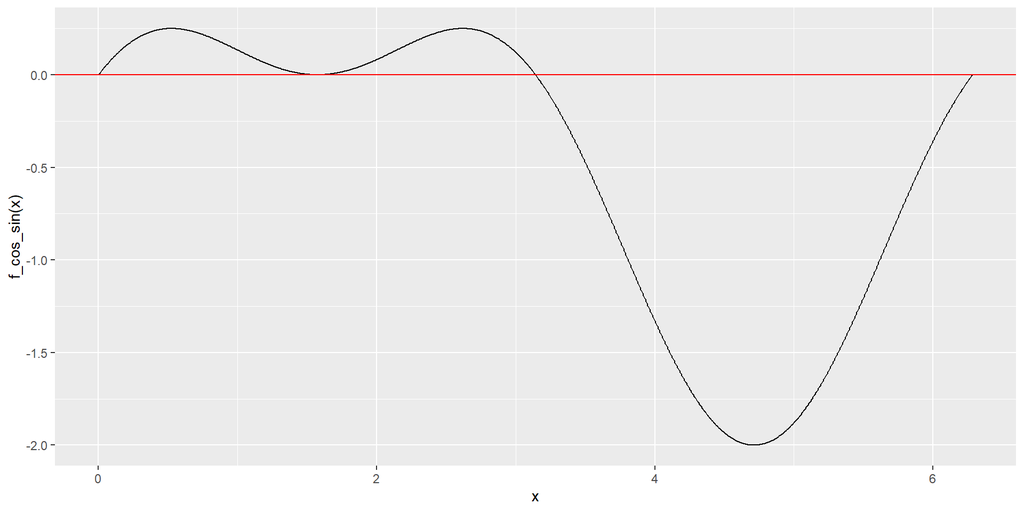

   ```r
   x = seq(from = 0, to=2*pi, length.out= 1000)
   qplot(x, f_cos_sin(x), geom=c('line')) +
     geom_hline(yintercept = 0, color = 'red')
   ```

   ```r
   bisect2 <- function(f,interval, answer, digit=8){
     tol= 0.5*10^(-digit)
     a =  interval[1]
     b =  interval[2]
     if (f(a)*f(b) > 0){
       return('f(a) and f(b) have the same sign')
     }

     count = 0
     c = (a+b)/2
     while(abs(answer - c)> tol){
         count = count + 1
         c = (a+b)/2
         if(f(a)*f(c) < 0){
           b = c
         }else{
           a = c
         }
     }
     root <- c

     cat("\tRoot:", formatC(root, format='f', digits=15 ), '\tAcc Digit: ', digit, "\tIteration: ", count, end='\n')
   }


   cat(' Actual Root:', formatC(pi, format='f', digits=15 ), end='\n\n')
   ```

   ```
   ##  Actual Root: 3.141592653589793
   ```

   ```r
   for (i in 1:15){
     bisect2(f_cos_sin, c(2.5,3.5), pi,i)
   }
   ```

   ```
   ##  Root: 3.125000000000000     Acc Digit:  1   Iteration:  3
   ##  Root: 3.140625000000000     Acc Digit:  2   Iteration:  6
   ##  Root: 3.141601562500000     Acc Digit:  3   Iteration:  10
   ##  Root: 3.141601562500000     Acc Digit:  4   Iteration:  10
   ##  Root: 3.141593933105469     Acc Digit:  5   Iteration:  17
   ##  Root: 3.141592979431152     Acc Digit:  6   Iteration:  20
   ##  Root: 3.141592621803284     Acc Digit:  7   Iteration:  23
   ##  Root: 3.141592651605606     Acc Digit:  8   Iteration:  25
   ##  Root: 3.141592653468251     Acc Digit:  9   Iteration:  29
   ##  Root: 3.141592653584667     Acc Digit:  10  Iteration:  33
   ##  Root: 3.141592653591943     Acc Digit:  11  Iteration:  37
   ##  Root: 3.141592653590124     Acc Digit:  12  Iteration:  39
   ##  Root: 3.141592653589782     Acc Digit:  13  Iteration:  43
   ##  Root: 3.141592653589797     Acc Digit:  14  Iteration:  46
   ##  Root: 3.141592653589793     Acc Digit:  15  Iteration:  48
   ```

3. By hand, compute a formula for Newton’s iteration for this particular choice of $f(x)$; i.e., write a formula for $x_{i+1}$ in terms of $x_{i}$.

   $$f(x) = cos^2(x) + sin(x) -1 \\f'(x) = -sin(2x) + cos(x) \\$$

   Tangent line $y$ at $x_0$:
   $$\begin{align*}
   y &=f'(x_0)(x-x_0) + f(x_0) \\
   0 &= f'(x_0)(x-x_0) + f(x_0) \\
   x_1 &= x_0 - \frac{f(x_0)}{f'(x_0)} \\
   x_{i+1} &= x_i - \frac{f(x_i)}{f'(x_i)} \\
   x_{i+1} &= x_i - \frac{cos^2(x_i) + sin(x_i) -1 }{-sin(2x_i) + cos(x_i)}\\
   x_{i+1} &= x_i - \frac{cos^2(x_i) + sin(x_i) -cos^2(x_i) - sin^2(x_i) }{-2sin(x_i)cos(x_i) + cos(x_i)}\\
   x_{i+1} &= x_i - \frac{sin(x_i)(1-sin(x_i))}{cos(x_i)(1 -2sin(x_i))}\\
   x_{i+1} &= x_i - tan(x_i)\frac{1-sin(x_i)}{1 -2sin(x_i)}\\
   \end{align*}$$
4. Set $x_0$ to 4.25, run 50 iterations of your Newton’s formula from
   3. to compute $\{x_i\}_{i=0,1,\ldots,50}$, and compute $e_i=|x_i-\pi|$ for all $i$. When does the iteration converge? Now plot $e_i / e_{i-1}$ over all $i$ until convergence. What is the convergence rate to $\pi$? **Note**: You do not have to write a general Newton’s function; just implement the specific iteration you calculated in part c).

   ```r
   #  Function: take x0 and return the x1
   f_Newton_iteration = function(x_i){
     return(x_i - tan(x_i)*(1-sin(x_i))/(1-2*sin(x_i)))
   }

   # Function: return the dataframe about convergence rate
   calculate_convergence = function(f, root, x_0, iter = 50, q = 1){
       #  Placeholder for {x_i} values
       x = rep(0, iter)
       #  Placeholder for {e_i} values
       e = rep(NA, iter)
       # Calculate x1 given x0 = 4.25
       x[1] = f(x_0)
       for(i in 2:iter){
         x[i] = f_Newton_iteration(x[i-1])
         e[i-1] = abs(x[i] - root)
       }
      ratio = e[2:iter]/(e[1:iter-1]^q)
      convergence_length = length(ratio[!is.na(ratio)])

      result = data.frame(iteration=1:(convergence_length),
                           err_ratio= ratio[1:convergence_length],
                          errors = e[1:convergence_length],
                          x = x[1:convergence_length])

   return(result)
   }
   ```

   The Sequence of approximations converges with rate $q$ if
   $$lim_{i\to \infty}\frac{\|e_{i+1}\|}{\|e_i\|^q} = C$$

   The iteration converge on the fifth iteration.  
   The convergent rate to $\pi$ is quadratic according to the graph below. The error ratio in the third graph is almost consistant starting from iteration 1.

   ```r
   ratio1 = calculate_convergence(f_Newton_iteration, pi, 4.25, 50, q = 1)
   ratio1.8 = calculate_convergence(f_Newton_iteration, pi, 4.25, 50, q = 1.8)
   ratio2 = calculate_convergence(f_Newton_iteration, pi, 4.25, 50, q = 2)
   head(ratio1)
   ```

   ```
   ##   iteration     err_ratio        errors         x
   ## 1         1 1.0177009e-01 1.3723724e-01 2.8872892
   ## 2         2 1.3522540e-02 1.3966647e-02 3.2788299
   ## 3         3 1.8878134e-04 1.8886454e-04 3.1555593
   ## 4         4 3.7366464e-08 3.5654100e-08 3.1417815
   ## 5         5 0.0000000e+00 1.3322676e-15 3.1415927
   ```

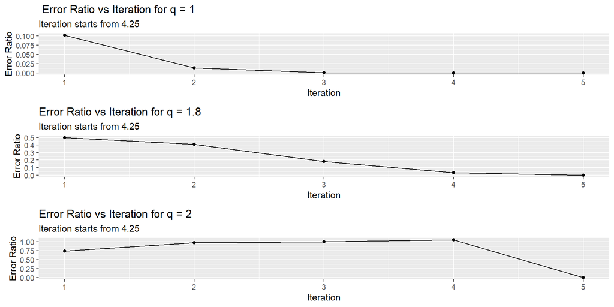

   ```r
   p1  = qplot(ratio1$iteration,
             ratio1$err_ratio,
             geom = c('path', 'point'),
             ylab='Error Ratio',
             xlab = 'Iteration') +
             ggtitle(' Error Ratio vs Iteration for q = 1') +
         labs(subtitle = 'Iteration starts from 4.25 ')
   p1.8  = qplot(ratio1.8$iteration,
             ratio1.8$err_ratio,
             geom = c('path', 'point'),
             ylab='Error Ratio',
             xlab = 'Iteration') +
             ggtitle('Error Ratio vs Iteration for q = 1.8') +
         labs(subtitle = 'Iteration starts from 4.25 ')
   p2  = qplot(ratio2$iteration,
             ratio2$err_ratio,
             geom = c('path', 'point'),
             ylab='Error Ratio',
             xlab = 'Iteration') +
             ggtitle('Error Ratio vs Iteration for q = 2') +
         labs(subtitle = 'Iteration starts from 4.25 ')



   ggarrange(p1,p1.8,p2, nrow=3)
   ```

5. Repeat d) with $x_0$=1.5. What is the convergence rate to $\pi/2$? If your answer is different from d), explain why.

   The convergence rate to $\pi/2$ is linear. In d), the error eventually reach 0 making $\frac{e_i}{e_{i-1}}$ drop to 0. In this e), the error drops at a constant rate around 0.5 before a drop and jump to 1. The $\frac{e_i}{e_{i-1}} = 1$ after iteration 22. After this iteration, the error remains the same at 0.00000000082858431 and making $\frac{e_i}{e_{i-1}} = 1$.

   Look at the plot of $f(x)$, the starting point at $x_0 = 1.5$ is very flat, meaning the Newton Convergence at this point very slow.

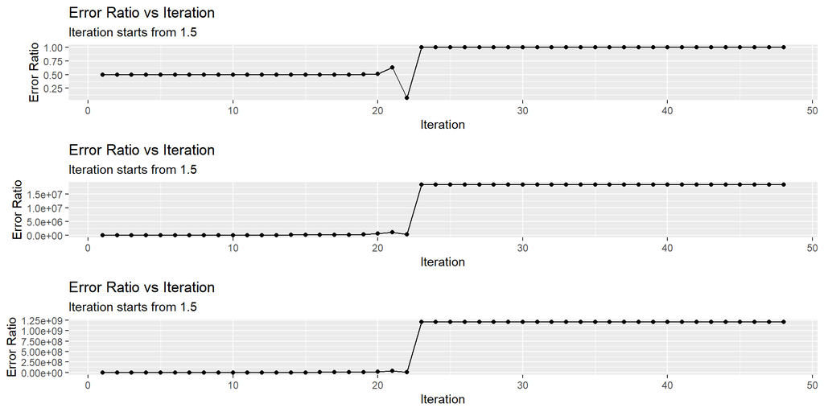

   ```r
   ratio1_1.5 = calculate_convergence(f_Newton_iteration, pi/2, 1.5, 50, q = 1)
   ratio1.8_1.5 = calculate_convergence(f_Newton_iteration, pi/2, 1.5, 50, q = 1.8)
   ratio2_1.5 = calculate_convergence(f_Newton_iteration, pi/2, 1.5, 50, q = 2)
   p1.5_1 = qplot(ratio1_1.5$iteration,
         ratio1_1.5$err_ratio,
         geom = c('path', 'point'),
         ylab='Error Ratio',
         xlab = 'Iteration') +
         ggtitle('Error Ratio vs Iteration') +
       labs(subtitle = 'Iteration starts from 1.5 ')
   p1.5_1.8 = qplot(ratio1.8_1.5$iteration,
         ratio1.8_1.5$err_ratio,
         geom = c('path', 'point'),
         ylab='Error Ratio',
         xlab = 'Iteration') +
         ggtitle('Error Ratio vs Iteration') +
       labs(subtitle = 'Iteration starts from 1.5 ')
   p1.5_2 = qplot(ratio2_1.5$iteration,
         ratio2_1.5$err_ratio,
         geom = c('path', 'point'),
         ylab='Error Ratio',
         xlab = 'Iteration') +
         ggtitle('Error Ratio vs Iteration') +
       labs(subtitle = 'Iteration starts from 1.5 ')
     ggarrange(p1.5_1, p1.5_1.8, p1.5_2, nrow = 3 )
   ```

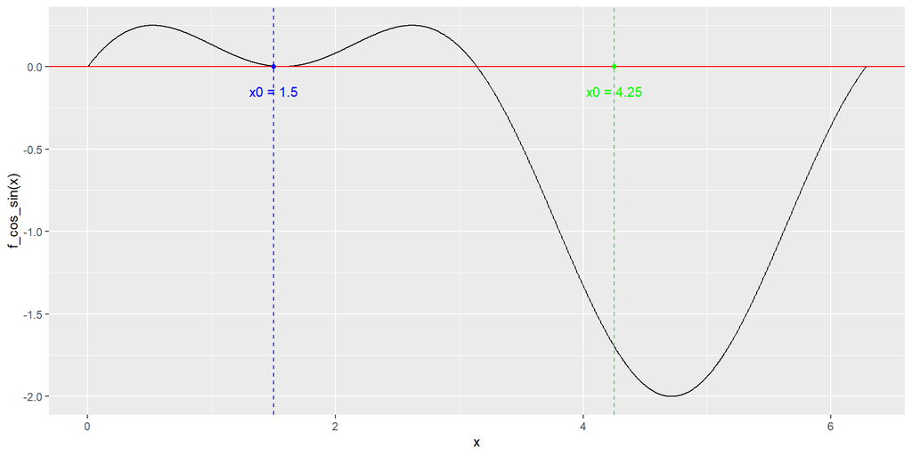

   ```r
     qplot(x, f_cos_sin(x), geom=c('line')) +
       geom_hline(yintercept = 0, color = 'red') +
       geom_vline(xintercept = 1.5, color = 'blue',linetype = "dashed") +
       geom_vline(xintercept = 4.25, color = 'green', linetype = "dashed") +
       geom_point(aes(x=1.5, y=0), colour="blue") +
       geom_text(aes(x=1.5,y=-0.15), label='x0 = 1.5', colour='blue')+
       geom_point(aes(x=4.25, y=0), colour="green") +
       geom_text(aes(x=4.25,y=-0.15), label='x0 = 4.25', colour='green')
   ```

   ```r
     ratio1_1.5
   ```

   ```
   ##    iteration   err_ratio        errors         x
   ## 1          1 0.499909277 1.7634270e-02 1.5355021
   ## 2          2 0.499977332 8.8155352e-03 1.5531621
   ## 3          3 0.499994334 4.4075678e-03 1.5619808
   ## 4          4 0.499998584 2.2037589e-03 1.5663888
   ## 5          5 0.499999646 1.1018763e-03 1.5685926
   ## 6          6 0.499999911 5.5093777e-04 1.5696945
   ## 7          7 0.499999979 2.7546884e-04 1.5702454
   ## 8          8 0.499999997 1.3773441e-04 1.5705209
   ## 9          9 0.500000007 6.8867206e-05 1.5706586
   ## 10        10 0.499999976 3.4433604e-05 1.5707275
   ## 11        11 0.500000022 1.7216801e-05 1.5707619
   ## 12        12 0.500000439 8.6084009e-06 1.5707791
   ## 13        13 0.500002816 4.3042042e-06 1.5707877
   ## 14        14 0.499996464 2.1521142e-06 1.5707920
   ```

   [output cut: 34 more lines]